# COVID-19 Forecast Evaluation

Delphi Group

August 10, 2021

## Select Forecasts

Filter to forecasters that have significant overlap in predictions with CMU-TimeSeries for the last 4 weeks.This is used primarily to ensure we don’t include inactive forecasters in the pairwise tournament rankings and that there is enough overlap for pairwise scores to be meaningful.

```r
if (file.exists(params$score_file)){
  score_cards = readRDS(params$score_file)
} else {
  stop(paste("File not found:", params$score_file))
}

if (file.exists(params$preds_file)){
  predictions = readRDS(params$preds_file)
  predictions = predictions %>% filter(signal == params$signal)
} else {
  stop(paste("File not found:", params$preds_file))
}

highlight_forecasters = params$highlight_forecasters
if (is.null(highlight_forecasters)){
  highlight_forecasters = predictions %>% distinct(forecaster)
}
if(is.null(params$wedge_forecasters)){
  wedge_forecasters = params$main_forecaster
} else {
  wedge_forecasters = params$wedge_forecasters
}

score_cards_tourney = score_cards
score_cards_main = score_cards %>%
                    filter(forecaster == params$main_forecaster) %>%
                    distinct(ahead, geo_value, target_end_date)
score_cards = semi_join(score_cards, score_cards_main)

recent_score_by_frcstr = score_cards %>%
                           filter(target_end_date > today() - 28) %>%
                           group_by(forecaster, ahead) %>%
                           summarize(num = sum(!is.na(wis))) %>%
                           pivot_wider(names_from = ahead,
                                       names_prefix = "num_",
                                       values_from = num)
recent_score_by_frcstr = recent_score_by_frcstr %>%
                           mutate(num_total = num_1 + num_2 + num_3 + num_4) %>%
                           arrange(desc(num_total))
print(recent_score_by_frcstr, n = Inf)
```

```
## # A tibble: 8 x 6
## # Groups:   forecaster [8]
##   forecaster               num_1 num_2 num_3 num_4 num_total
##   <chr>                    <int> <int> <int> <int>     <int>
## 1 CMU-TimeSeries             313   508   708   795      2324
## 2 COVIDhub-baseline          313   508   708   795      2324
## 3 COVIDhub-ensemble          313   508   708   795      2324
## 4 JHU_UNC_GAS-StatMechPool   313   508   708   795      2324
## 5 JHUAPL-Bucky               313   508   708   795      2324
## 6 CU-select                  313   507   706   793      2319
## 7 UVA-Ensemble               312   506   705   791      2314
## 8 LANL-GrowthRate            311   505   704   791      2311
```

```r
main_forecasts = recent_score_by_frcstr[recent_score_by_frcstr$forecaster == params$main_forecaster,]$num_total

active_forecasters = recent_score_by_frcstr[recent_score_by_frcstr$num_total > main_forecasts * 0.80,]$forecaster

# save for pairwise tournament
score_cards_tourney = score_cards_tourney %>%
                filter(forecaster %in% active_forecasters)
```

Next, filter to forecasters of interest for line plots and find common locations.

```r
score_cards = score_cards %>% filter(forecaster %in% highlight_forecasters)

# TODO: Use evalcast::intersect_averagers after merging the kill-cards updates
forecaster_coverage = score_cards %>%
                        group_by(ahead, geo_value, target_end_date) %>%
                        summarise(num_forecasts = n())
max_forecasts = max(forecaster_coverage$num_forecasts)
table(forecaster_coverage$num_forecasts)
```

```
##
##    3
## 6700
```

```r
common_forecasts = forecaster_coverage %>%
                            filter(num_forecasts == max_forecasts) %>%
                            select(ahead, geo_value, target_end_date)


# score_cards = semi_join(score_cards, common_forecasts)
```

## Line plots

Now we make line plots: one line per ahead and forecaster, as a function of forecast date. Here we use the mean as the aggregator function, and we look at WIS and coverage-80.

```r
# Define mean and median functions that deal with missingness well
Mean = function(x) mean(x, na.rm = TRUE)
Median = function(x) median(x, na.rm = TRUE)

summarize_var = function(df, var, aggr = Mean) {
  df_by_date = df %>%
    group_by(forecaster, ahead, target_end_date) %>%
    summarize(var = aggr(!!as.symbol(var))) %>%
    ungroup()
  df_overall = df %>%
    group_by(forecaster, ahead) %>%
    summarize(var_overall = aggr(!!as.symbol(var))) %>%
    ungroup() %>% group_by(ahead) %>%
    arrange(var_overall, .by_group = TRUE) %>%
    ungroup() %>%
    mutate(order = row_number())
  df_sum = full_join(df_by_date, df_overall, by = c("forecaster", "ahead"))
}

# From https://stackoverflow.com/questions/15282580/
color_picker = function(n) {
  qual_col_pals = brewer.pal.info[brewer.pal.info$category == 'qual',]
  unlist(mapply(brewer.pal, qual_col_pals$maxcolors, rownames(qual_col_pals)))
}

line_plot = function(df, var = "wis", ylab = var, ylim = NULL, aggr = Mean) {
  df_sum = summarize_var(df, var, aggr)
  df_sum$ahead = factor(paste("ahead =", df_sum$ahead))

  ggplot(df_sum, aes(x = target_end_date, y = var)) +
    geom_line(aes(color = forecaster, linetype = forecaster)) +
    geom_point(aes(color = forecaster)) +
    facet_wrap(vars(ahead), scales = "free") +
    labs(x = "Date", y = ylab) +
    coord_cartesian(ylim = ylim) +
    scale_color_manual(values = color_picker(length(unique(forecaster))))
}
```

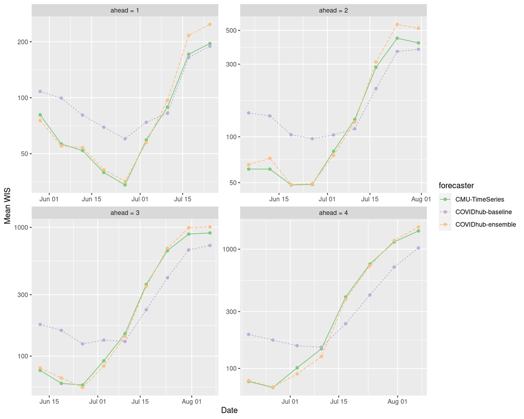

```r
line_plot(score_cards, var = "wis", ylab = "Mean WIS") + scale_y_log10()
```

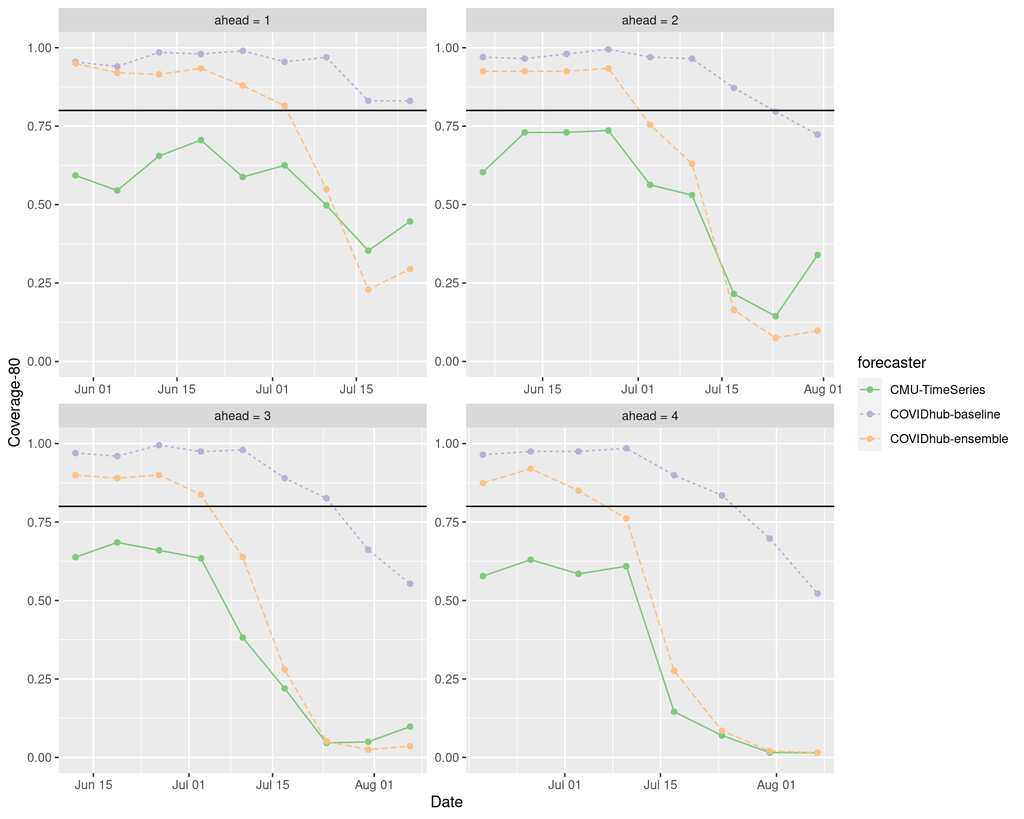

```r
line_plot(score_cards, var = "coverage_80", ylab = "Coverage-80", ylim = c(0,1)) +
  geom_hline(yintercept = 0.8)
```

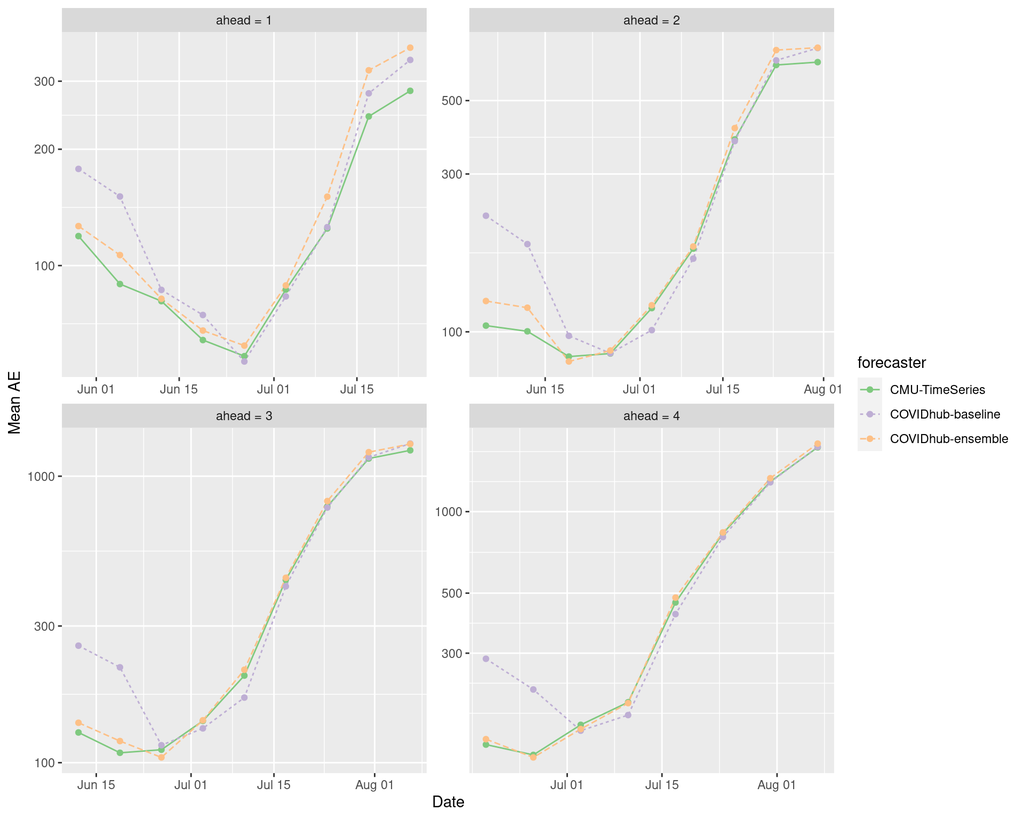

```r
line_plot(score_cards, var = "ae", ylab = "Mean AE") + scale_y_log10()
```

## Scaling by baseline

We scale each score, per location and forecast date, by the COVIDhub-baseline score; then we take the mean or median.

Important note on the order of operations here: scale then aggregate. The other way around: aggregate then scale, would be a simple post-adjustment applied to the metrics we computed earlier. This way: scale then aggregate, results in a different final metric altogether. It is potentially interesting as it provides a nonparametric spatiotemporal adjustment; assuming that space and time effects are *multiplicative*, we’re directly “canceling them out” by taking ratios.

```r
# Note to self: mutate_at() gave me a weird bug below! From now on, better use
# mutate() with across() instead ...
scale_df = function(df, var, base_forecaster = "COVIDhub-baseline") {
  df %>% select(-c(forecast_date)) %>%
    distinct() %>%
    pivot_wider(id_cols = c(geo_value, target_end_date, ahead),
                names_from = "forecaster", names_prefix = var,
                values_from = var) %>%
    mutate(across(starts_with(var), ~ .x /
                !!as.symbol(paste0(var, base_forecaster)))) %>%
    pivot_longer(cols = starts_with(var), names_to = "forecaster",
                 values_to = "scaled") %>%
    mutate(forecaster = substring(forecaster, nchar(var) + 1)) %>%
    filter(forecaster != base_forecaster)
}
```

Here are now line plots for median scaled WIS.

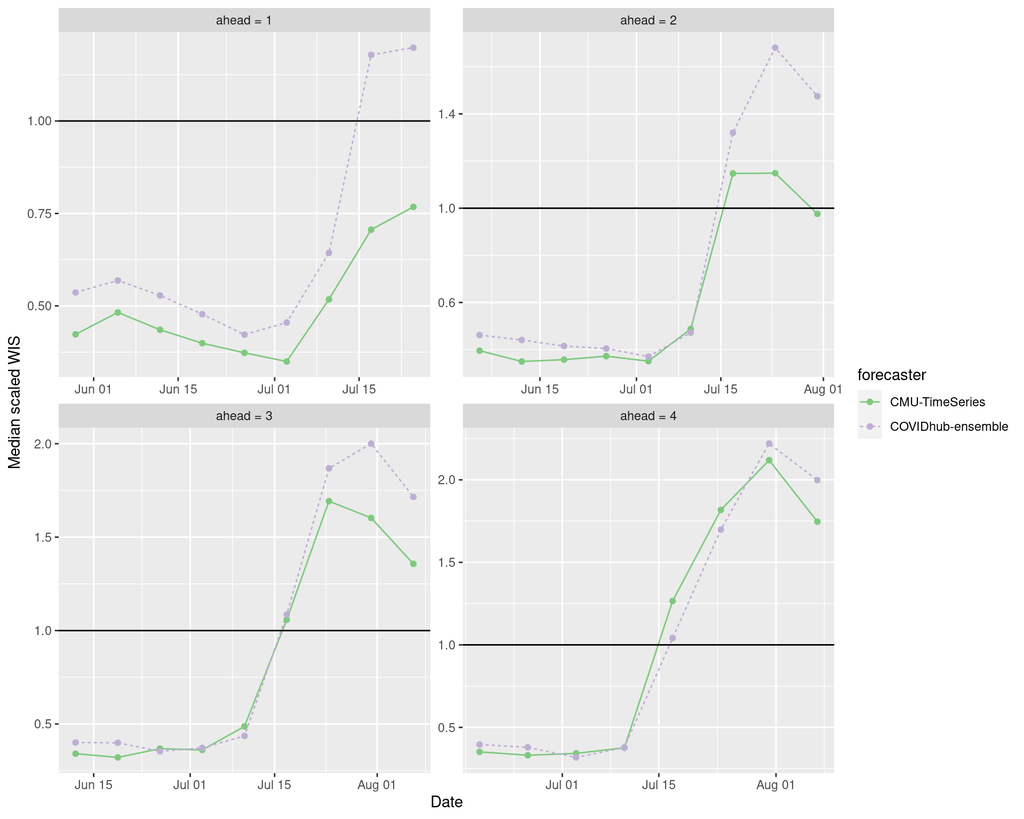

```r
line_plot(scale_df(score_cards, var = "wis", base_forecaster = params$base_forecaster), var = "scaled",
          ylab = "Median scaled WIS", aggr = Median) + geom_hline(yintercept = 1)
```

## Wedge plots

To give a fuller view of the coverage of forecasts, we create a wedge plot per ahead:

```
## CMU-TimeSeries
```

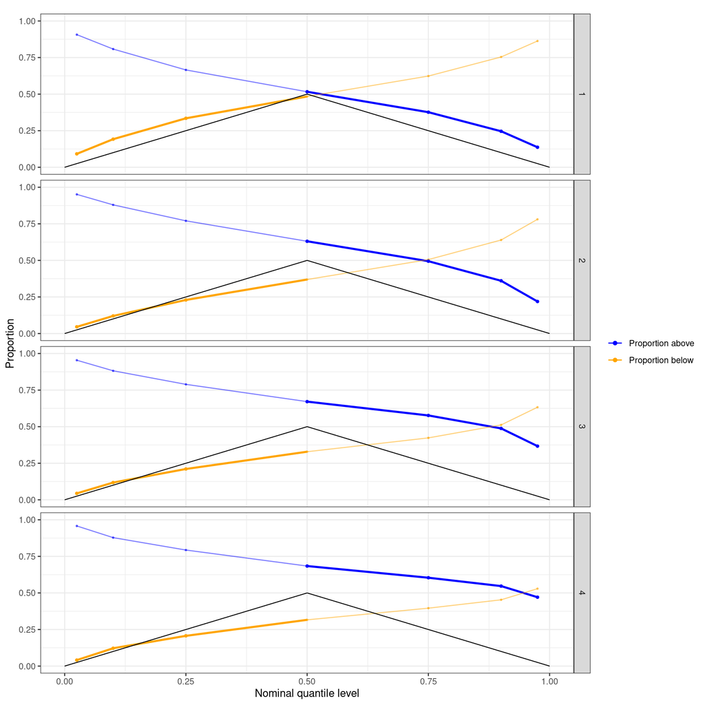

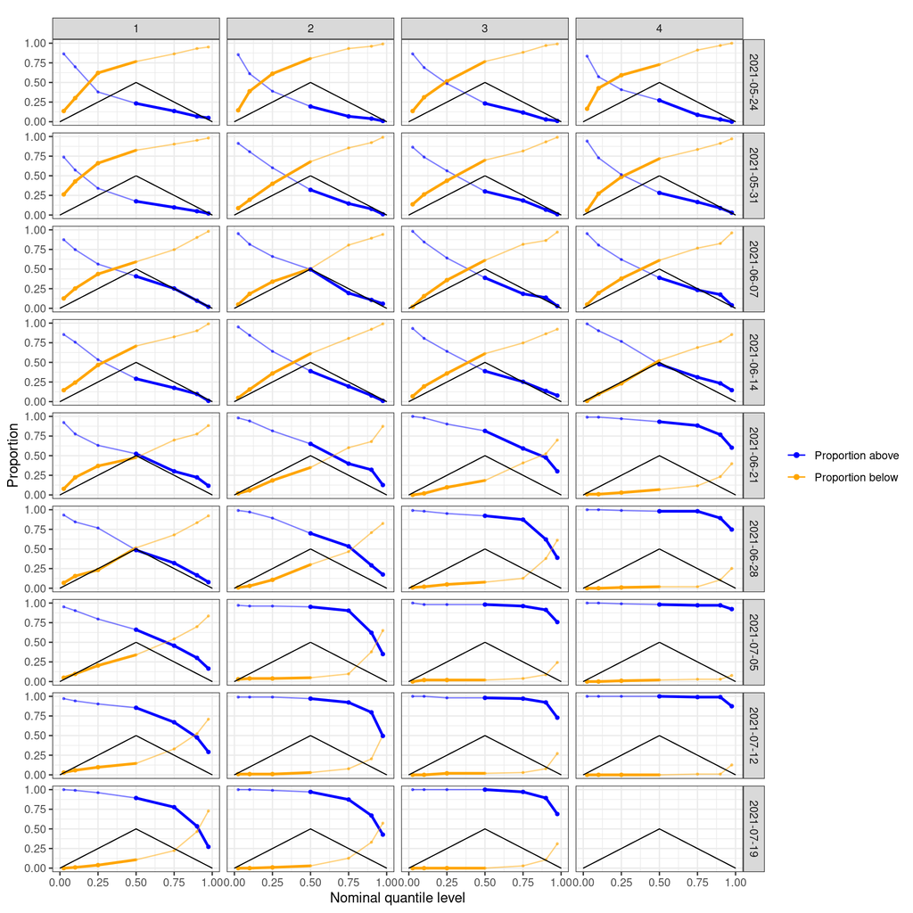

```r
for (forecaster_name in wedge_forecasters){
  cat(forecaster_name)
  type_chars = nchar(score_cards$geo_value[1])
  f_preds = predictions %>% filter(forecaster == forecaster_name,
                                     nchar(geo_value) == type_chars)
  geo_val = f_preds$geo_value[1]
  if (geo_val == "us"){
    f_geo_type = "nation"
  } else if (nchar(geo_val) == 2){
    f_geo_type = "state"
  } else {
    f_geo_type = "county"
  }
  print(plot_calibration(f_preds, grp_vars = c("ahead"), avg_vars = c("geo_value", "forecast_date"), type = "wedgeplot", facet_rows = "ahead", geo_type = f_geo_type))
  if(params$verbose_wedges){
    print(plot_calibration(f_preds, grp_vars = c("ahead", "forecast_date"), avg_vars = c("geo_value"), type = "wedgeplot", facet_cols = "ahead", facet_rows = "forecast_date", geo_type = f_geo_type))
  }
}
```

## Pairwise tournament

We run a pairwise tournament. This is inspired by Johannes Bracher’s analysis (and similar ideas in the literature). Except, the order of operations here is different: scale then aggregate (whereas Johannes did: aggregate then scale). The motivation for this was explained above (thinking of it as providing a nonparametric spatiotemporal adjustment), as was the fact that the order of operations really makes a difference.

For each pair of forecasters $f$ and $g$, we compute:

$$\theta_{fg} = A\bigg\{ \frac{S(f;\ell,d,a)}{S(g;\ell,d,a)} \;:\; \text{common
locations $\ell$, forecast dates $d$, and ahead values $a$} \bigg\}$$

where $S$ is a score of interest, say WIS, and $A$ is an aggregator of interest, say the mean. Important note: we aggregate over *all common locations, dates, and ahead values*, which may differ for each pair $f,g$. To compute an overall metric for forecaster $f$, we use:

$$\theta_f = \bigg( \prod_g \theta_{fg} \bigg)^{1/F}.$$

the geometric mean of all pairwise comparisons of $f$ to other forecasters (here $F$ is the total number of forecasters). Another interesting option would be to define $(\theta_f)_{f \in F}$ as the top left singular vector of the matrix $(\theta_{fg})_{f,g \in F}$, which we’ll also investigate.

```r
pairwise_tournament = function(df, var, aggr = Mean) {
  forecasters = unique(df$forecaster)
  theta_mat = matrix(NA, length(forecasters), length(forecasters))
  rownames(theta_mat) = colnames(theta_mat) = forecasters
  for (f in forecasters) {
    result =  scale_df(df, var, base_forecaster = f) %>%
      group_by(forecaster) %>%
      summarize(v = aggr(scaled))
    theta_mat[result$forecaster, f] = result$v
  }

  # Convert to data frame for convenience with ggplot
  theta_df = as.data.frame(theta_mat) %>%
    mutate(Forecaster1 = forecasters) %>%
    pivot_longer(cols = -Forecaster1, names_to = "Forecaster2",
                 values_to = "value")

  # Compute overall metrics two ways: geometric mean, SVD
  theta_vec1 = exp(rowMeans(log(theta_mat), na.rm = TRUE))
  diag(theta_mat) = 1 # so the SVD won't fail; undo it later
  theta_vec2 = as.numeric(svd(theta_mat, nu = 1)$u)
  names(theta_vec2) = names(theta_vec1)
  diag(theta_mat) = NA

  return(list(mat = theta_mat, df = theta_df, vec1 = theta_vec1,
              vec2 = theta_vec2))
}
```

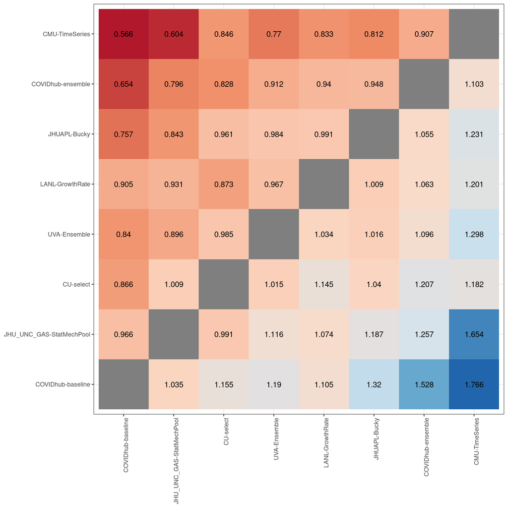

```r
#score_cards_tourney = score_cards_tourney %>% filter(geo_value != "as")
theta = pairwise_tournament(score_cards_tourney, var = "wis", aggr =
                              function(x) median(x, na.rm = TRUE))
ranked_list = rownames(theta$mat)[order(theta$vec1)]
colors = colorRampPalette(brewer.pal(n = 6, name = "RdBu"))(30)
ggplot(theta$df, aes(x = factor(Forecaster2, levels = rev(ranked_list)),
                     y = factor(Forecaster1, levels = rev(ranked_list)))) +
  geom_tile(aes(fill = value)) +
  geom_text(aes(label = round(value, 3))) +
  scale_fill_gradientn(colours = colors) +
  labs(x = NULL, y = NULL) +
  theme_bw() + theme(legend.position = "none",
                     axis.text.x = element_text(angle = 90, hjust = 1))
```

```r
# Overall metric (computed via GM of pairwise metrics):
knitr::kable(data.frame(rank = 1:length(theta$vec1), forecaster = ranked_list,
                        theta = sort(theta$vec1), row.names = NULL))
```

| rank | forecaster | theta |
| --- | --- | --- |
| 1 | CMU-TimeSeries | 0.7526355 |
| 2 | COVIDhub-ensemble | 0.8730979 |
| 3 | JHUAPL-Bucky | 0.9647304 |
| 4 | LANL-GrowthRate | 0.9876254 |
| 5 | UVA-Ensemble | 1.0148504 |
| 6 | CU-select | 1.0604208 |
| 7 | JHU_UNC_GAS-StatMechPool | 1.1601938 |
| 8 | COVIDhub-baseline | 1.2792145 |